# BIOS719 HW06

Kuei-Yueh (Clint) Ko

# Background

This is the homework 06 of the course BIOS719 GLM

# Set environment

```r
library(tidyverse)
library(pROC)
source("./codesnippet_r/f.glm.diag.R")
```

# Import data

The number of deaths from leukemia and other cancers among survivors of the Hiroshima atom bomb are shown in Table 7.12, classified by teh radiation dose received. The data refer to deaths during teh period 1950-1959 among survivors who Ire aged 25 to 64 years in 1950 (from data set 13 of Cox and Snell 1981, attributed to Otake 1979)

```r
### Data: Table 7-12.txt
dat_leukemia = tribble(
    ~radiation, ~leukemia, ~other, ~total,
    "0",      13, 378, 391,
    "1-9",     5, 200, 205,
    "10-49",   5, 151, 156,
    "50-99",   3,  47,  50,
    "100-199", 4,  31,  35,
    "200",    18,  33,  51)
dat_leukemia = dat_leukemia %>% mutate(
    middle = c(0.0, 5.0, 29.5, 74.5, 149.5, 250.0))
print(dat_leukemia)
```

| radiation | leukemia | other | total | middle |
| --- | --- | --- | --- | --- |
| 0 | 13 | 378 | 391 | 0.0 |
| 1-9 | 5 | 200 | 205 | 5.0 |
| 10-49 | 5 | 151 | 156 | 29.5 |
| 50-99 | 3 | 47 | 50 | 74.5 |
| 100-199 | 4 | 31 | 35 | 149.5 |
| 200 | 18 | 33 | 51 | 250.0 |

# Q7.1 (a)

**Obtain a suitable model to describe the dose-response relationship betIen radiation and the proportional cancer mortality rates for leukemia (logistic regression)**

```r
fit = glm(cbind(leukemia, other) ~ middle,
          data = dat,
          family = binomial(link = "logit"), x = T)
print(fit)
```

```
Call:  glm(formula = cbind(leukemia, other) ~ middle, family = binomial(link = "logit"),
    data = dat, x = T)

Coefficients:
(Intercept)       middle
    -3.5654       0.0116

Degrees of Freedom: 5 Total (i.e. Null);  4 Residual
Null Deviance:      54.35
Residual Deviance: 1.021    AIC: 26.69
```

# Q7.2 (b)

**Describe how will the model describe the data**

### First I examine the standardized deviance residual.

Based on the plot, I do not see non linear relationship between the residual and covariate “middle radiation”.

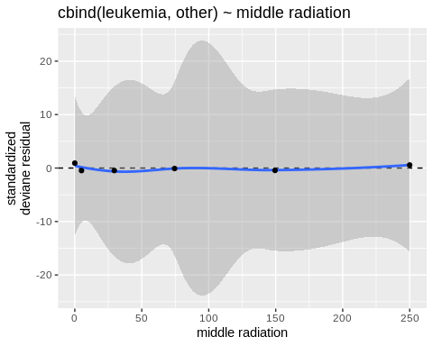

```r
dat = cbind(dat_leukemia, f.glm.diag(fit))
gp  = ggplot(dat, aes(x = middle, y = sdres))
gp  = gp +
    geom_hline(yintercept = 0, lty = 2) +
    geom_smooth(method = "loess", span = 0.9) +
    geom_point() +
    labs(title = "cbind(leukemia, other) ~ middle radiation",
         x = "middle radiation", y = "standardized\ndeviane residual")
print(gp)
```

### Next observe the deviance.

Since deviance (1.020765) is much less than the degree of freedom of residuals (4), the model is accepted. If the deviance is much larger than the degree of freedom, the model needs to be improved.

```r
summary(fit)
```

```
Call:
glm(formula = cbind(leukemia, other) ~ middle, family = binomial(link = "logit"),
    data = dat, x = T)

Deviance Residuals:
       1         2         3         4         5         6
 0.67247  -0.41264  -0.41833  -0.08544  -0.41969   0.19957

Coefficients:
             Estimate Std. Error z value Pr(>|z|)
(Intercept) -3.565422   0.212192 -16.803  < 2e-16 ***
middle       0.011603   0.001484   7.821 5.25e-15 ***
---
Signif. codes:  0 ‘***’ 0.001 ‘**’ 0.01 ‘*’ 0.05 ‘.’ 0.1 ‘ ’ 1

(Dispersion parameter for binomial family taken to be 1)

    Null deviance: 54.3509  on 5  degrees of freedom
Residual deviance:  1.0208  on 4  degrees of freedom
AIC: 26.686

Number of Fisher Scoring iterations: 4
```

### Then, I compare the observed and fitted probability to visualize the prediction of the model.

The results seems acceptable when comparing the value of observed and fitted probability

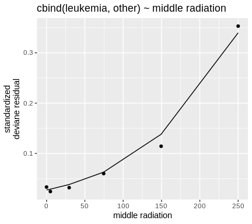

### The performance of the model can be further examined using percent of concordance and c-statistics

First, I created the model of $n_i = 1$ situation in order to calculate the concordance and c-statistics.

```r
### create n_i = 1 situation
dat = as.data.frame(
    rbind(cbind(middle = rep(dat_leukemia$middle,
                             dat_leukemia$leukemia),
              n = 1, y = 1),
          cbind(middle = rep(dat_leukemia$middle,
                             dat_leukemia$total - dat_leukemia$leukemia),
              n = 1, y = 0)
    ) # end rbind
) # end as.data.frame

### fit the model
fit_n1 = glm(cbind(y, n-y) ~ middle, data = dat,
             family = binomial(link = "logit"))
### check if the coefficients are the same
cat("grouped data\n", fit$coefficients, "\n", "n_i = 1\n", fit_n1$coefficients)
```

```
grouped data
 -3.565422 0.01160255
 n_i = 1
 -3.565422 0.01160255
```

I wrote the function to calculate the results. Note that the function has been tested using the class example and the output is exactly the same as SAS output.

```r
concordance(fit_n1)
```

```
$Concordance
[1] 0.6100446

$Discordance
[1] 0.203249

$Tied
[1] 0.1867063

$Pairs
[1] 40320

$`Somers D`
[1] 0.4067956

$gamma
[1] 0.500183

$`tau-a`
[1] 0.04164762

$c
Area under the curve: 0.7034
```

It turns out that the percent of concordance reaches at around 60% and the c-statistic is about 0.7, which is higher than random.

Below is the ROC curve of the model I fitted.

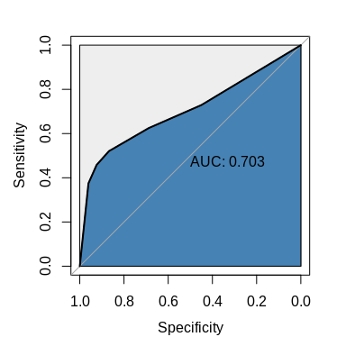

# 7.1 (c)

**Interpret the results**

When other factors are fixed, I can infer that the change of odds ratio given 1 unit increase in radiation is $e^{\beta_1} = 1.01$

```r
exp(fit$coefficients[2])
```

```
 middle
1.01167
```

# 7.1 (d)

**Evaluate appropriateness of the logit link**

In this part, I test the $\alpha$ value in the general family of link function

$$g(p_i; \alpha) = log \Big\{
\frac{ (1 - p_i)^{-\alpha} - 1 }{ \alpha }
\Big\}$$

Here I calculate the z value to fit a new model

```r
### declare function to calculate z value
dG = function(p, alpha){
    log(1 - p) / ((1 - p)^alpha - 1) - alpha^{-1}
} # end func
### calcualte the z value of current fitted model with logit link (alpha = 1)
dat   = dat_leukemia
dat$z = dG(fit$fitted.values, 1)
### fit a new model with z value
fit_link = glm(cbind(leukemia, other) ~ middle + z, data = dat,
               family = binomial(link = "logit"))
### test the parameter of z
anova(fit_link, test = "Chisq")
```

```
Analysis of Deviance Table

Model: binomial, link: logit

Response: cbind(leukemia, other)

Terms added sequentially (first to last)

       Df Deviance Resid. Df Resid. Dev  Pr(>Chi)
NULL                       5     54.351
middle  1   53.330         4      1.021 2.819e-13 ***
z       1    0.386         3      0.635    0.5345
---
Signif. codes:  0 ‘***’ 0.001 ‘**’ 0.01 ‘*’ 0.05 ‘.’ 0.1 ‘ ’ 1
```

**Since the test is not significant (pvalue = 0.53 > 0.05), I do not reject the null that $\alpha = 1$ under 0.05 level.**

# 7.1 (e)

**Provide predicted probability of leukemia (and 95% CI) for the highest dose group**

The predicted probability of leukemia for the highest dose group (middle = 250.0).

Since
$$logit(p) = \eta = \beta_0 + \beta_1 * x$$

The probability can be derived into the formula below
$$p = \frac{1}{1 + exp\{ -\eta \}}$$

```r
beta = fit$coefficients ; names(beta) = NULL
eta  = beta[1] + beta[2] * 250
prob = 1 / (1 + exp(-eta))
cat("E[P(leukemia | middle = 250] =", prob)
```

```
E[P(leukemia | middle = 250] = 0.3396658
```

95% confidence interval of true probability given highest dose group.

```r
### our input vector
X = cbind(c(1, 250))
### covariance matrix of coefficients
covb = summary(fit)$cov.unscaled
### S.E. of eta
se = t(X) %*% covb %*% X %>% sqrt %>% as.vector
### eta = beta[1] + beta[2] * 250
eta = t(X) %*% fit$coef %>% as.vector
ci_eta = eta + c(-1, 1) * qnorm(1 - 0.05 / 2) * se
names(ci_eta) = c("lower", "upper")
### using the 95% CI of eta to calcualte CI of probability
ci_prob = 1 / (1 + exp(-ci_eta))
print(ci_prob)
```

```
    lower     upper
0.2301103 0.4695678
```